# Make reports and scientific paper in Markdown

12 July 2021

## Writing e-book and print book

## Library xaringan

Sharingan là một trong 3 nhãn lực hùng mạnh nhất thế giới Naruto,đây là đôi mắt tạo cho những fan ruột của bộ truyện tranh này rất nhiều cảm hứng tìm hiểu và đam mê sở hữu. Con mắt Tả Luân Nhãn (Sharingan) không phải bẩm sinh mà có; thay vào đó, nó sẽ xuất hiện khi người đó bị đưa vào tình huống đe dọa đến tính mạng hoặc chứng kiến cảnh tượng đau lòng như thấy người thân của mình hi sinh.

Trong Markdown đây là một gói thư viện dựa trên nền tảng JavaScript, giúp người lập trình viên có thể thao tác và tạo ra các giao diện khác nhau trên nền website, HTML..Tác giả của gói này Yihui Xie, là một người rất thích truyện tranh của Nhật Bản.

[figure not shown]

Xaringan

## Yihui Xie

## Tác giả

Yihui Xie (tiếng Trung: 谢益辉) là một nhà thống kê và nhà khoa học dữ liệu người Trung Quốc. Anh là tác giả chính của gói Knitr mã nguồn mở dùng để phân tích dữ liệu bằng ngôn ngữ lập trình R, và cũng đã viết cuốn sách Tài liệu động với R và Knitr. Anh ấy làm kỹ sư phần mềm cho RStudio.

Từ năm 2013, Yihui Xie làm thiết kế lập trình cho RStudio IDE. Anh đã đóng góp khá lớn vào công việc thiết kế nghiên cứu cách trình bày **Reproducible Research** - Nghiên cứu khoa học khả lặp.

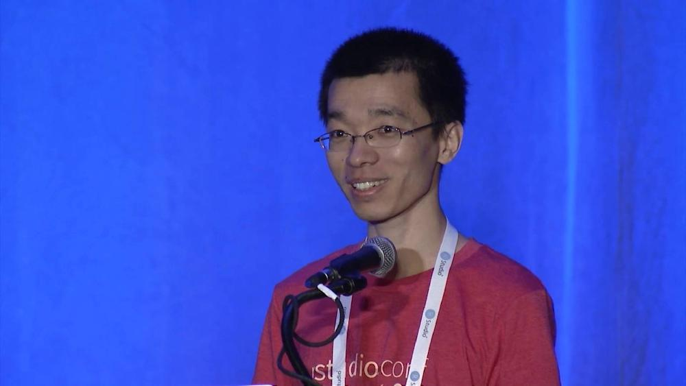

Yihui Xie

## Reproducible Research

## Nội dung nghiên cứu khả lặp

**“Nghiên cứu khoa học khả lặp”** - reproducible research đang là xu thế mới của giới khoa học và những package sẽ giúp người nghiên cứu khoa học hoàn toàn có thể viết báo cáo cho riêng mình.**“Nghiên cứu khoa học khả lặp”** là loại nghiên cứu khoa học không chỉ có báo cáo kết quả nghiên cứu mà còn bao gồm đầy đủ các bước thực hiện, đồng thời công bố các thông tin cần thiết (dữ liệu, thuật toán sử dụng,…) để người khác có thể tiến hành lại nghiên cứu nhằm xác nhận tính đúng đắn và mở rộng nghiên cứu dựa trên nền tảng nghiên cứu cũ. Ở đây “reproducible” hay “reproducibility” mang nghĩa có khả năng lặp lại, có khả năng thực hiện lại nghiên cứu đã được công bố.

Sử dụng Rmarkdown và knitr là sự lựa chọn tối ưu cho xu hướng “reproducible research” này. Các bước tuần tự (sequence) đưa ra kết quả dựa trên YAML metadata, code chunks, text nhằm đưa ra một quá trình từ đầu từ chạy code, hiển thị dữ liệu, show kết quả và cuối cùng là report dưới nhiều dạng như beamer_presentation, ioslides_presentation, revealjs::revealjs_presentation…

Quy trình của Rmarkdown khá đơn giản nhưng lại cung cấp một quy trình khá đầy đủ giúp người nghiên cứu có thể cảm nhận từng bước xây dựng, giải quyết và cụ thể hóa đưa ra kết quả của bài toán. Từ đó có thể nghiên cứu, phát triển sâu hơn các nội dung nghiên cứu tiếp theo.

## Process of RPRS

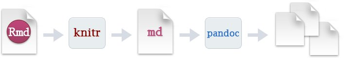

The Reporducible Research

## Writing e-book with pagedown

Click here for more information

## Making the Business Card

## Business Card

For more information, click here

## Making the CV Resume

## Personal CV to apply for any purposes

For more information, click here

## Making Poster for presentation

## Making the scientific paper

## Scientific Paper

Bài báo khoa học là bản báo cáo kết quả nghiên cứu của một người hay một nhóm nào đó. Bài báo khoa học được đăng tải phải có 5 bước:

– Lựa chọn chủ đề nghiên cứu phù hợp

– Thiết kế nghiên cứu

– Thu thập số liệu

– Phân tích số liệu

– Trình bày kết quả

Phương pháp viết bài báo khoa học gồm 4 phần chính (theo chuẩn IMRAD):

– Giới thiệu: I (Introduction) nêu vấn đề đã được chọn lựa để nghiên cứu

– Phương pháp: M (Method) sử dụng phương pháp nào và tiến hành ra sao?

– Kết quả: R (Result) phát hiện gì từ việc nghiên cứu.

– Và: A (And)

– Bàn luận: D (Discusion) ý nghĩa của những phát hiện từ nghiên cứu.

## Making the scientific paper

## Scientific Paper

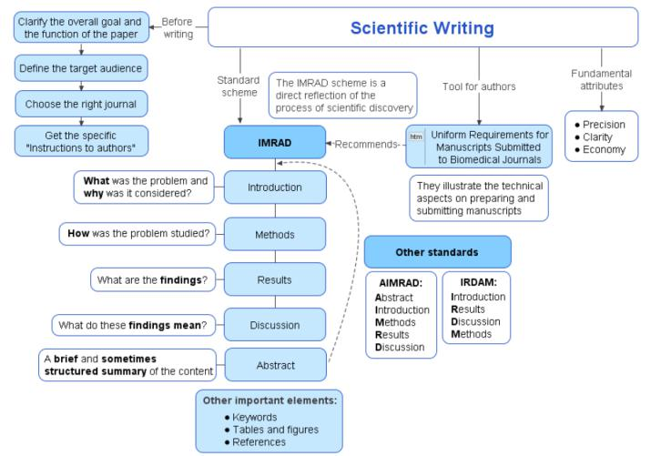

Scientific paper

## How to write the scientific in Rmarkdown

Trước tiên, xem qua một format ngắn của một bài báo cáo:

1. Bài báo cáo 1
2. Bài báo cáo 2

## LaTex

## Sơ lược về LaTex

\(LaTex\) là gì:

- Là 1 ngôn ngữ định dạng (document markup language) giống như Word, Powerpoint ở chỗ là đều cho ra những văn bản được định dạng theo mong muốn của người sử dụng nhưng có sự khác biệt lớn. Word thì gõ chữ cái và sử dụng công cụ đồ hoạ để thực hiện việc định dạng văn bản, còn LaTex là “lập trình” ra văn bản.
- Tiền thân là TeX, một ngôn ngữ định dạng do Donald Knuth phát minh, rất khó sử dụng.
- LaTeX được phát minh bởi Leslie Lamport, dựa trên TeX nhưng dễ sử dụng hơn rất nhiều. Cho ra chất lượng bản in cực cao cùng cấu trúc văn bản rất logic và đồng bộ.
- Tự động hóa rất nhiều so với làm bằng tay của Word.

Có thể sử dụng 1 trong các trình soạn thảo phổ biến như:

- MiKTeX (Bundle) (Windows)
- Texmaker (Windows, Mac, Linux)
- Overleaf (Collaborative Online Editor)

## Latex và Rmarkdown

Nội dung này sẽ trình bày một ví dụ ngắn gọn về \(LaTex\): Trước tiên công thức phải được đặt giữa cặp dấu: \(Formula\) theo mục đích sử dụng. Ví dụ, chúng ta gõ: A=x+1 thông thường, còn đây là \(LaTex\), \(A=x+1\). Còn nếu chúng ta gõ: \[A=x+1\] thì công thức tự động xuống dòng.

Nếu muốn gõ phân số: \(\frac{a}{b};\frac{x+1}{y-1}\)

Gõ số mũ: \(a_{n+1} ;a_n+1; z^{p+q};z^p+q\)

Gõ giới hạn: \(\lim \dfrac{1}{x}=0; \lim\limits_{x\to x_0} \dfrac{f(x)-f(x_0)}{x-x_0}\)

Gõ tích phân: \(\int\limits_{1}^{2} x^2+x+1\)

## Thực hành viết trên Rmarkdown

Click here to open .Rmd file in Rmarkdown